# Portugal i verden gennem tusindvis af år

Kapitel 1 · Portugals historie

## 1.1 Før Portugal blev PortugalPortugal i dag

[figure not shown]

- Cirka dobbelt så stort som Danmark
- Godt 10 mio. indbyggere
- Portugisisk tales af 250 til 300 mio. mennesker
- Sådan har det ikke altid været

## Fra Allis Ubbo til Olisipo

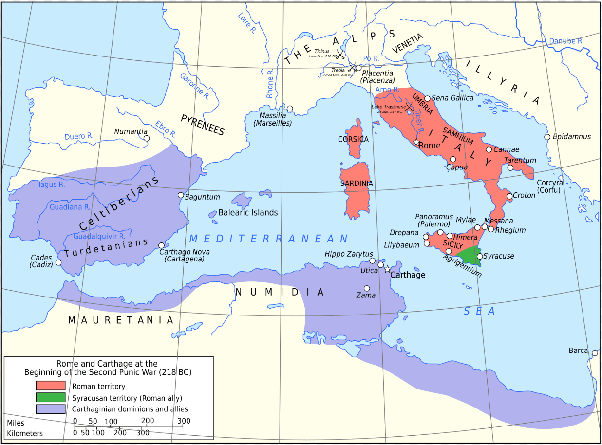

- Karthago grundlagde Allis Ubbo, begyndelsen til Lissabon
- Rom vandt de tre puniske krige (264-146 f.v.t.)
- Romernes Olisipo havde teater, bade, rindende vand og arena
- Myten: Odysseus grundlagde byen

## Viriathus

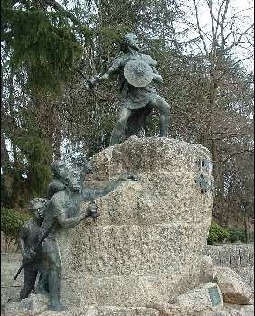

Han ledte et oprør mod romerne i 140’erne f.v.t. Hvorfor står der statuer af ham i både Spanien og Portugal?

Han er blevet et symbol på national identitet

At kalde ham spansk eller portugisisk frihedskæmper er en anakronisme.

## Romerriget falder

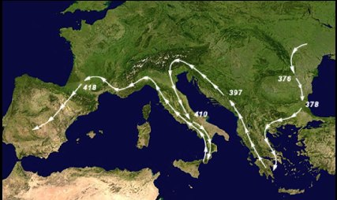

- 400-tallet: den vestlige del af Romerriget bryder sammen
- Visigoterne kommer østfra og bider sig fast på den iberiske halvø
- Fra 475 er de konger i eget land

## 1.2 Araberne og den kristne reconquistaFeudalisme

- Et liv med landbrug til eget forbrug
- En lokal magthaver med våben beskyttede bønderne
- Bønderne betalte med naturalier
- Samfundsmodellen kom til at kendetegne middelalderen

## Al-Andalus

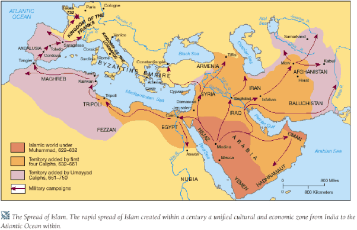

- 711: ca. 7000 muslimske soldater krydser Gibraltarstrædet
- 714: Lissabon bliver til Al-Isbunah
- Ikke-muslimer er dhimmi og betaler en særlig skat
- Ny teknologi, videnskab og vandingsmetoder

## Kun en kamp mellem kristne og muslimer?

Middelalderen skildres ofte sådan. Hvad overser man så?

- I store dele af tiden var der fred
- Kristne kæmpede mod kristne og muslimer mod muslimer
- Man allierede sig også med religiøse modstandere
- Meget gensidig afsmitning i videnskab, økonomi og kultur

## Reconquista

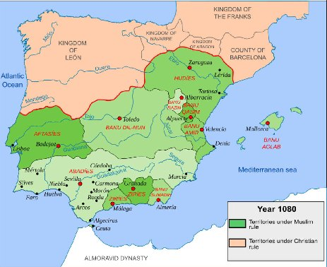

- Generobringen begynder for alvor i 1000-tallet
- 1095: paven opfordrer til korstog
- 1492: de sidste muslimer fordrives fra Spanien
- Samme år udvises jøderne

## Levn eller beretning?

Et vidne siger: “Jeg så min nabo slå en ældre dame med et bat.”

- **Beretning:** naboen slog damen
- **Levn:** vidnet *siger*, at naboen slog damen

Beretning kommer længst, men er mest risikabel. Levn er den forsigtige løsning.

## 1.3 Kongeriget PortugalAfonso 1.

[figure not shown]

- 1128-1147: tre krige samler Portugal
- 1139: sejren over muslimerne ved Ourique
- 1147: Lissabon erobres med hjælp fra korsfarere
- Paven godkender ham som konge

## Slaget ved Ourique

[figure not shown]

Hvordan forklarer billedet fra 1793 sejren?

Guddommelig indgriben: et lys fra Kristus ledte de kristne til sejr

Samme slags fortælling som Dannebrog, der faldt ned fra himlen i 1219.

## Portugal i 1150

- Portugal er kristent
- Portugal er blevet til i en kamp for kristenheden
- Portugal er allieret med England
- Portugal er IKKE Spanien

## Hvorfor ud i verden?

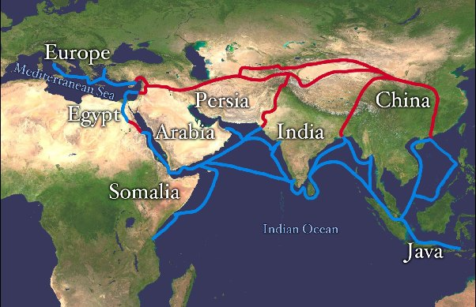

- Europæerne ville have silke og krydderier fra Asien
- Varerne kom dyrt gennem italienske og arabiske købmænd
- Der manglede guld og sølv i Europa
- Håbet om præstekongen Johannes’ rige

## Aljubarrota 1385

[figure not shown]

- Joao 1. besejrer en hær fra Castilien
- England sender riddere og bueskytter
- Alliancen sikres med Philippa af Lancaster
- Portugal får sit eget kongehus

## 1.4 Opdagelsesrejser og slaveriSagres

[figure not shown]

- Henrik Søfareren samler eksperter
- Praktisk erfaring møder teoretisk videnskab
- Nye skibe: karaveller og karakker
- Kanoner, kort og navigation

## Columbus

Columbus ville sejle vestpå til Asien. Hvorfor sagde portugiserne nej?

Eksperterne i Sagres vidste, at jorden var langt større, end Columbus troede

## Ptolemæus’ verdenskort

[figure not shown]

- Afrika går måske hele vejen til Sydpolen
- Portugiserne holder muligheden åben for, at Ptolemæus tager fejl

## Madeira: en mini-model

- Varmt vejr, vand og træ: perfekt til sukker
- Men der mangler arbejdskraft
- Fra ca. 1430: slaver fra De Kanariske Øer og Afrika
- Kolonial plantageproduktion med slaver

## Var slaveri ok i middelalderen?

- Kirken: kristne må ikke holde andre kristne som slaver
- Muslimer og andre ikke-kristne må gerne gøres til slaver
- Muslimer gjorde også kristne til slaver
- 1450’erne: pavens velsignelse til arveligt slaveri

## Langs Afrikas kyst

[figure not shown]

- Diogo Cao udforsker de afrikanske floder
- Bartolomeu Dias når Afrikas sydspids, Kap det Gode Håb
- Skørbug, storme og kampe med lokale befolkninger
- Dyrt og farligt, lidt som rumfart i det 20. århundrede

## 1.5 Vasco da Gama og imperiet i AsienSøvejen til Indien

[figure not shown]

- 1497: Vasco da Gamas flåde sejler fra Belem i Lissabon
- Med tolke, der kan arabisk og afrikanske sprog
- Hjem igen to år senere

## Mødet i Indien

Hvordan blev portugiserne modtaget, da de kom til Indien?

Herskeren var ikke imponeret over deres varer og gaver

Ville portugiserne handle med Indien, skulle de betale med guld.

## Et imperium af knudepunkter

[figure not shown]

- Havne og øer erobres, og der bygges forter
- Portugiserne bestemmer told, priser og skatter
- Omkring 1550 er Portugal verdens supermagt

## Terror og stolthed

Hvordan fortalte erobrerne om drabene på muslimer, fx på Goa?

Med stolthed, ligesom korsfarerne havde gjort

## Tordesillastraktaten 1494

- Paven er mægler mellem Spanien og Portugal
- Vest for linjen: Spanien. Øst for linjen: Portugal
- Brasilien stikker ud i den portugisiske zone
- Aftalen binder ingen andre

## 1.6 Fra stormagt til udkantHvem fik glæde af rigdommen?

- Købmænd, kaptajner og adelen blev rigere
- For mange betød guldet bare inflation
- Bønderne mærkede meget lidt
- Kirker, klostre og slotte blev flottere

## En spansk konge

- 1578: kong Sebastiao og hæren går til grunde i Nordafrika
- 1580-1640: personalunion med Spanien
- Krigene med hollænderne koster Portugal dyrt
- 1640: et kup giver Portugal sin egen konge igen

## Brasilien og slavehandelen

- Sukker og kaffe kræver arbejdskraft
- 1540-1700: næsten en million afrikanske slaver til Brasilien
- I alt små 4 mio.: flest af alle over Atlanten
- Brasilien holder længst fast i slavehandelen

## 1.7 Jordskælvet, Napoleon og 1800-talletJordskælvet i 1755

[figure not shown]

Jordskælv, tsunami og brande: 30.000 til 60.000 døde. Hvordan forklarede man det?

- **Kirken:** Guds vilje eller straf
- **Oplysningstænkerne:** natur, fornuft og videnskab

## Pombal

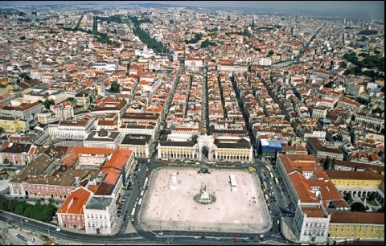

- Lissabon genopbygges med brede gader i rektangulære mønstre
- Import af slaver til Portugal forbydes
- Opgør med adelen og jesuiterordenen

## Hoffet flytter til Brasilien

[figure not shown]

- 1807: briterne sejler hoffet til Brasilien
- Ca. 10.000 personer fra Portugals elite
- Rio er imperiets hovedstad i 13 år
- Begyndelsen på Brasiliens uafhængighed

## Ikke længere en stormagt

[figure not shown]

- Tre franske invasioner, drevet tilbage af briterne
- Borgerkrig 1828-1834 om tronen og forfatningen
- Fra 1834 konstitutionelle monarker
- Briterne stopper Portugals planer i Afrika

## 1.8 Et stille diktaturFra republik til diktatur

- 1910: revolution mod kongehuset og kirken
- 1911: republik med en ny grundlov
- 1910-1926: 9 præsidenter og 44 regeringer
- 1926: generalerne tager magten ved et kup

## Salazar

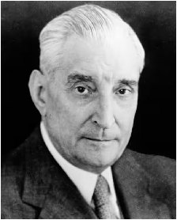

- Økonom og universitetsprofessor
- Finansminister, fra 1932 premierminister
- Reelt diktator i Portugal

## “The world’s best dictator”?

Sådan skrev Life Magazine om Salazar i 1940. Hvad viser citatet?

Vurderinger af personer afhænger af den tid og sammenhæng, de foretages i

## Estado Novo

- Imod demokrati: det skaber splid
- Imod kommunisme: kamp mellem klasser
- Korporatisme: det, portugiserne har til fælles
- Rerum Novarum: arbejdere og arbejdsgivere i gensidig respekt

## 1.9 Estado Novo og 2. verdenskrigEt stille diktatur?

[figure not shown]

Ingen massemøder og ingen statuer af føreren. Men hvordan fremstilles Salazar på plakaten fra 1933?

## Undertrykkelse

- Hemmeligt politi, PIDE
- Kirken og skriftestolen som overvågning
- Kvinder uden en sekundær uddannelse må ikke stemme
- Ingen koncentrationslejre, men hemmelige fængsler

## Neutral under 2. verdenskrig

- Allieret med Storbritannien, men tæt på Franco
- Omkring en million flygtninge gennem Lissabon
- Portugisiske diplomater udsteder pas til jøder
- Flag på halv stang, da Hitler døde

## Efter krigen

- Med i NATO fra starten, ligesom Danmark
- EFTA i stedet for EEC, ligesom Danmark
- 1958: Delgado vil fyre Salazar, og valget bliver fusket
- 1965: Delgado findes dræbt i Spanien

## 1.10 Kolonikrigene, nellikerevolutionen og Portugal i dagDe unge rejser ud

[figure not shown]

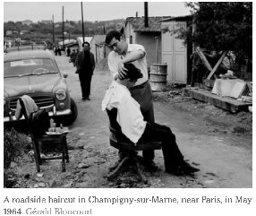

- Protester mod regimet og krigene i Afrika
- Gæstearbejdere i Frankrig, Tyskland, Danmark og Brasilien

## Kolonikrigene

[figure not shown]

13 års krige i Guinea-Bissau, Angola og Mozambique og ca. 150.000 døde. Hvorfor accepterede de andre NATO-lande krigene?

Oprørerne var for manges vedkommende støttet af Sovjetunionen

## Nellikerevolutionen 1974

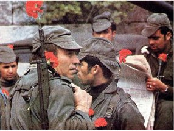

- Officerer i hæren gennemfører et kup
- Folk sætter blomster i soldaternes geværløb
- General Spinola står for overgangen
- Soldaterne kommer hjem fra Afrika

## Mod demokrati

- Kommunisterne under Cunhal prøver at få magten
- November 1975: kupforsøg fra venstreekstremister
- Valget til den grundlovgivende forsamling: flertal for liberalt demokrati
- Kommunisterne får 12,5 %

## Portugal i dag

[figure not shown]

- Medlem af EU fra 1986
- Krisen i 2008: krisehjælp for 78 mia. euro
- Homoseksualitet var forbudt indtil 1982
- I dag nogle af de mest liberale love